# Tutorial on propensity score matching and inverse probability of treatment weighting

Katherine Siegel and Laura Dee

2024-06-17

## Description

This tutorial demonstrates how to use propensity score matching and inverse probability of treatment weighting using a real dataset from [Siegel et al. 2022](https://doi.org/10.1007/s10113-022-01950-y). The dataset for the entire western US is very large and unwieldy, so you’ll work with a subset of data for a single year in Colorado.

## Set up

Load the packages used for data manipulation (tidyverse, sf), making a directed acyclic graph (ggdag), matching (MatchIt), weighting (ipw), and regression models (lme4).

## The context

The Siegel et al. 2022 study examines the effect of forest management (through the proxy of land ownership) on annual burn probability in forests of the western US. Specifically, it looks at the effect of federal (treatment) vs. private (control) ownership on wildfire occurrence in sample units.

### Directed acyclic graph

Here’s a DAG for the research question:

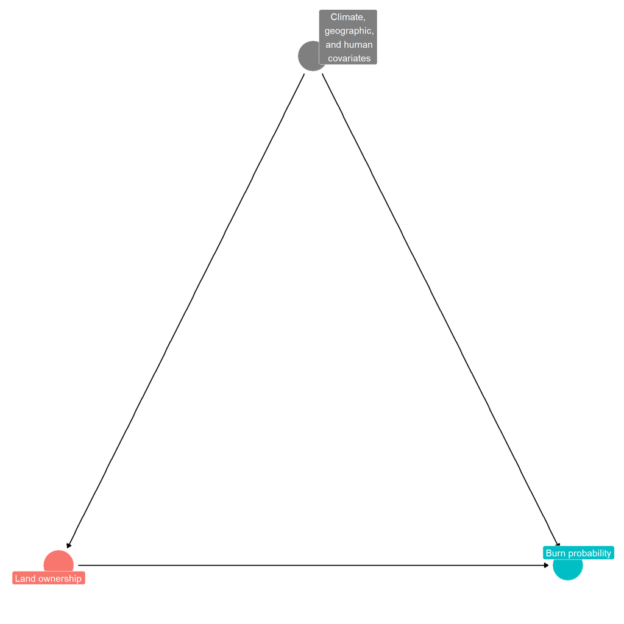

## The data

The data are in the file *matching_ipw_data.csv.*

### Variable names

- state: the state the sample unit is from (Colorado)
- UID: a unique identifier for each sample unit
- year: the year that the fire and climate data is from (2002)
- burned: whether or not the unit burned in 2002 (0 = unburned, 1 = burned)
- prot_cat_recl: the ownership class. 0 = private, 1 = federal
- dist_rds_km: distance to the nearest road, in kiometers
- slope: slope, in degrees
- aspect_srai: solar radiation aspect index
- elev_km: elevation, in 1000 m
- lon: longitude
- lat: latitude
- pdsi_avg_season: seasonal average Palmer Drought Severity Index value (fall, spring, summer, winter)
- soil_avg_season: seasonal average soil moisture (fall, spring, summer, winter)
- tmmn_avg_season: seasonal average minimum temperature (fall, spring, summer, winter)
- tmmx_avg_season: seasonal average maximum temperature (fall, spring, summer, winter)
- vs_max_season: seasonal average maximum wind speed (fall, spring, summer, winter)
- total_precip_season: total seasonal precipitation (fall, spring, summer, winter)
- prev_yr_precip: total precipitation in the previous year

## Data exploration

### What’s the breakdown of private (value = 0) vs. federal (value = 1) units?

Units on federal (=1) and private (=0) land

| Var1 | Freq |
| --- | --- |
| 0 | 22877 |
| 1 | 60654 |

### What’s the breakdown of units that burned (value = 1) in 2002 vs. units that did not burn (value = 0)?

Units that burned (=1) or did not burn (=0) in 2002

| Var1 | Freq |
| --- | --- |
| 0 | 82189 |
| 1 | 1342 |

### How do the private (in red) vs federal (in blue) units differ in terms of potential confounders?

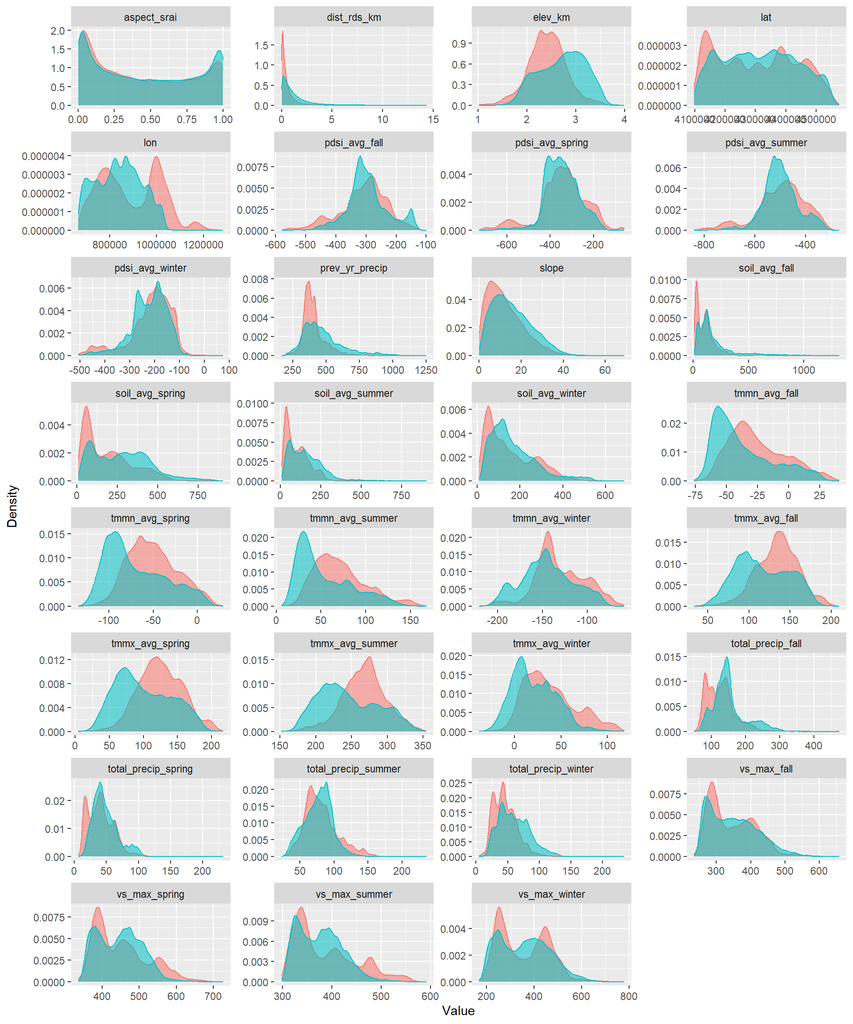

## Run naive regression

We could just run a naive regression, ignoring the potential impact of confounders. There are some highly correlated covariates in the model, but let’s ignore them for now. Let’s see what that would yield:

Coefficient estimates for naive model

| Variable | Estimate | Std. Error | p value |
| --- | --- | --- | --- |
| (Intercept) | -14.088 | 3.606 | 0.000 |
| prot_cat_recl1 | 1.229 | 0.095 | 0.000 |
| dist_rds_km | -0.079 | 0.029 | 0.007 |
| slope | 0.019 | 0.003 | 0.000 |
| aspect_srai | 0.149 | 0.084 | 0.077 |
| elev_km | 1.627 | 0.215 | 0.000 |
| pdsi_avg_winter | -0.014 | 0.002 | 0.000 |
| pdsi_avg_spring | -0.021 | 0.003 | 0.000 |
| pdsi_avg_summer | 0.036 | 0.004 | 0.000 |
| pdsi_avg_fall | -0.004 | 0.003 | 0.143 |
| soil_avg_winter | 0.000 | 0.001 | 0.597 |
| soil_avg_spring | 0.006 | 0.001 | 0.000 |
| soil_avg_summer | -0.002 | 0.001 | 0.200 |
| soil_avg_fall | -0.002 | 0.001 | 0.003 |
| tmmn_avg_winter | -0.112 | 0.011 | 0.000 |
| tmmn_avg_spring | 0.054 | 0.026 | 0.035 |
| tmmn_avg_summer | -0.095 | 0.022 | 0.000 |
| tmmn_avg_fall | 0.131 | 0.026 | 0.000 |
| tmmx_avg_winter | 0.133 | 0.012 | 0.000 |
| tmmx_avg_spring | -0.017 | 0.021 | 0.431 |
| tmmx_avg_summer | 0.265 | 0.021 | 0.000 |
| tmmx_avg_fall | -0.395 | 0.029 | 0.000 |
| vs_max_winter | 0.044 | 0.004 | 0.000 |
| vs_max_spring | -0.038 | 0.005 | 0.000 |
| vs_max_summer | -0.007 | 0.005 | 0.157 |
| vs_max_fall | -0.045 | 0.006 | 0.000 |
| total_precip_winter | -0.152 | 0.008 | 0.000 |
| total_precip_spring | -0.034 | 0.007 | 0.000 |
| total_precip_summer | 0.130 | 0.007 | 0.000 |
| total_precip_fall | 0.044 | 0.005 | 0.000 |
| prev_yr_precip | -0.003 | 0.003 | 0.196 |

## Use matching to overcome issues with observed confounding variables

### Match the data

Match the data on the observable covariates, using the MatchIt package. You can play around with the settings to see how it affects the matched data you end up with.

#### Assess match quality

Take a look at the quality of the matches: how many units were matched? Control = private units, Treated = federal units

Breakdown of matched and unmatched units

|  | Control | Treated |
| --- | --- | --- |
| All (ESS) | 22877 | 60654 |
| All | 22877 | 60654 |
| Matched (ESS) | 14948 | 14948 |
| Matched | 14948 | 14948 |
| Unmatched | 7929 | 45706 |
| Discarded | 0 | 0 |

What are the covariate means in the matched dataset for the treated (federal) and control (private) units? What was the covariate balance after matching?

Covariate balance of matched dataset

|  | Means Treated | Means Control | Standardized Mean Difference |
| --- | --- | --- | --- |
| distance | 0.6175678 | 0.6158332 | 0.0096477 |
| elev_km | 2.5052956 | 2.4861501 | 0.0409920 |
| slope | 13.3465764 | 13.1363850 | 0.0224325 |
| aspect_srai | 0.4447073 | 0.4419590 | 0.0079176 |
| lon | 850238.5413322 | 845110.8319396 | 0.0538222 |
| lat | 4318398.5515081 | 4321862.9614627 | -0.0288425 |
| dist_rds_km | 0.5719176 | 0.5294726 | 0.0312499 |
| prev_yr_precip | 415.8943671 | 413.7827803 | 0.0140391 |
| vs_max_fall | 333.4133663 | 330.1582820 | 0.0466353 |
| vs_max_winter | 337.3945009 | 332.5827535 | 0.0457741 |
| vs_max_spring | 433.4856168 | 430.1375435 | 0.0567933 |
| vs_max_summer | 369.8875435 | 367.1452368 | 0.0611912 |
| total_precip_fall | 135.8052582 | 136.7384265 | -0.0197269 |
| total_precip_winter | 49.3254616 | 48.9911025 | 0.0139092 |
| total_precip_spring | 43.3871421 | 44.1957453 | -0.0412558 |
| total_precip_summer | 74.2241771 | 73.3899518 | 0.0414806 |
| tmmx_avg_fall | 129.5226786 | 130.7270984 | -0.0374211 |
| tmmx_avg_winter | 30.7934172 | 31.4597940 | -0.0284709 |
| tmmx_avg_spring | 117.5956204 | 118.7956694 | -0.0295246 |
| tmmx_avg_summer | 262.2030818 | 263.8178129 | -0.0392109 |
| tmmn_avg_fall | -29.4589912 | -28.5876594 | -0.0359584 |
| tmmn_avg_winter | -136.7152350 | -135.5822407 | -0.0391606 |
| tmmn_avg_spring | -56.5789403 | -55.5111944 | -0.0313322 |
| tmmn_avg_summer | 64.6933592 | 65.6339087 | -0.0305103 |
| pdsi_avg_fall | -307.5831549 | -306.0611676 | -0.0220174 |
| pdsi_avg_winter | -221.5624610 | -223.2038400 | 0.0228779 |
| pdsi_avg_spring | -351.5044822 | -352.3478726 | 0.0106643 |
| pdsi_avg_summer | -504.4897199 | -504.5666533 | 0.0010718 |
| soil_avg_fall | 124.4666176 | 124.9689368 | -0.0027606 |
| soil_avg_winter | 163.4902551 | 165.5248863 | -0.0191280 |
| soil_avg_spring | 211.0054857 | 215.2656766 | -0.0247016 |
| soil_avg_summer | 113.2454955 | 114.3370128 | -0.0108724 |

Comparison of standardized mean differences in the covariate values in the full vs. matched dataset

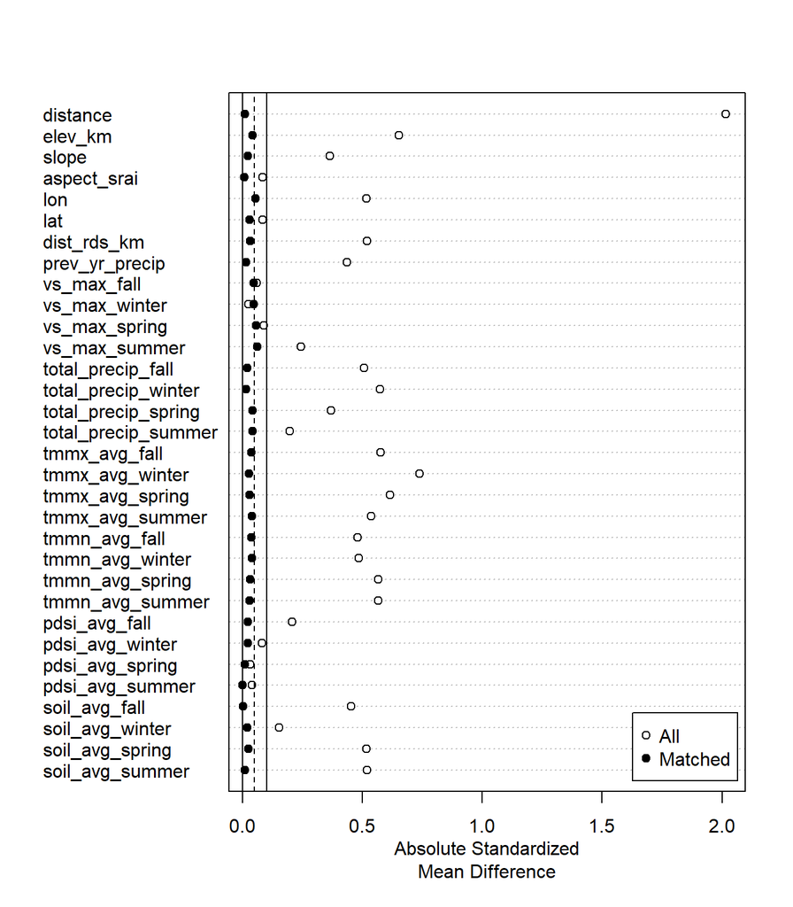

### Analyze the matched dataset

#### Extract the matched data

First, you’ll need to extract the matched data and use the UIDs from the matched data to subset the full dataset for analysis.

#### Model the effect of ownership/management on wildfire probability

Again, there are correlated covariates, but let’s just ignore them

Coefficient estimates for model with matching

| Variable | Estimate | Std. Error | p value |
| --- | --- | --- | --- |
| (Intercept) | -27.300 | 7.568 | 0.000 |
| prot_cat_recl1 | 1.013 | 0.115 | 0.000 |
| dist_rds_km | -0.033 | 0.097 | 0.731 |
| slope | 0.023 | 0.006 | 0.000 |
| aspect_srai | 0.135 | 0.139 | 0.331 |
| elev_km | 1.770 | 0.403 | 0.000 |
| pdsi_avg_winter | -0.019 | 0.004 | 0.000 |
| pdsi_avg_spring | -0.024 | 0.006 | 0.000 |
| pdsi_avg_summer | 0.033 | 0.008 | 0.000 |
| pdsi_avg_fall | -0.002 | 0.006 | 0.789 |
| soil_avg_winter | -0.001 | 0.001 | 0.394 |
| soil_avg_spring | 0.010 | 0.002 | 0.000 |
| soil_avg_summer | -0.003 | 0.003 | 0.334 |
| soil_avg_fall | -0.003 | 0.001 | 0.046 |
| tmmn_avg_winter | -0.072 | 0.020 | 0.000 |
| tmmn_avg_spring | -0.045 | 0.044 | 0.300 |
| tmmn_avg_summer | -0.140 | 0.042 | 0.001 |
| tmmn_avg_fall | 0.206 | 0.050 | 0.000 |
| tmmx_avg_winter | 0.165 | 0.023 | 0.000 |
| tmmx_avg_spring | -0.039 | 0.038 | 0.295 |
| tmmx_avg_summer | 0.492 | 0.041 | 0.000 |
| tmmx_avg_fall | -0.628 | 0.056 | 0.000 |
| vs_max_winter | 0.051 | 0.008 | 0.000 |
| vs_max_spring | -0.085 | 0.012 | 0.000 |
| vs_max_summer | 0.003 | 0.010 | 0.780 |
| vs_max_fall | -0.040 | 0.013 | 0.002 |
| total_precip_winter | -0.274 | 0.018 | 0.000 |
| total_precip_spring | -0.132 | 0.014 | 0.000 |
| total_precip_summer | 0.015 | 0.015 | 0.312 |
| total_precip_fall | -0.003 | 0.010 | 0.755 |
| prev_yr_precip | 0.055 | 0.006 | 0.000 |

## Use weighting to overcome issues with observed confounding variables

### Weight the data

Use the package ipw

#### What’s the range of weights?

```
## [1]    1.00 6069.64
```

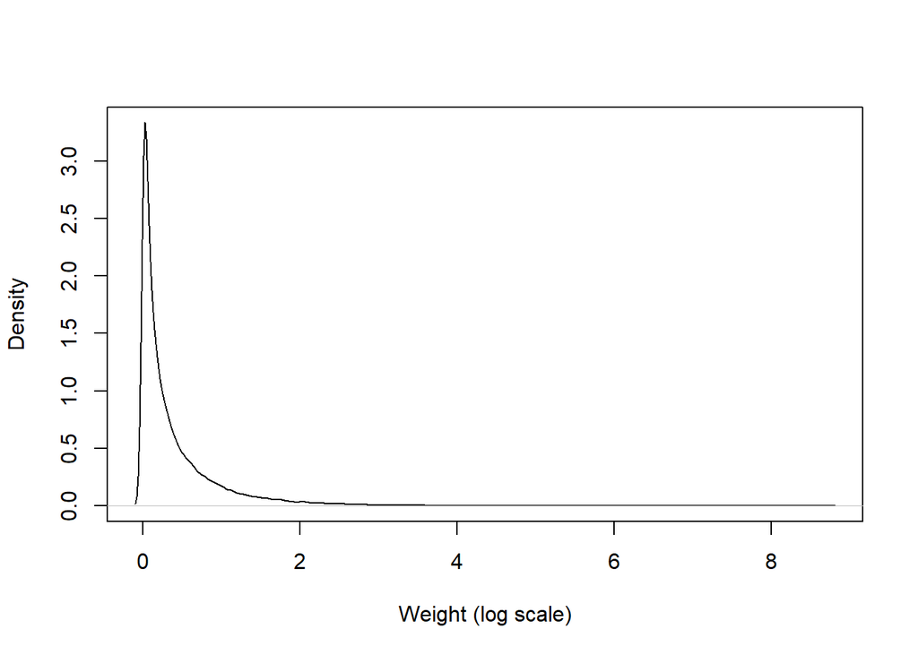

### Model the effect of ownership

Coefficient estimates for model with weighting

| Variable | Estimate | Std. Error | p value |
| --- | --- | --- | --- |
| (Intercept) | -11.151 | 2.821 | 0.000 |
| prot_cat_recl1 | 0.921 | 0.054 | 0.000 |
| dist_rds_km | -0.014 | 0.026 | 0.581 |
| slope | 0.011 | 0.003 | 0.000 |
| aspect_srai | 0.077 | 0.066 | 0.245 |
| elev_km | 1.890 | 0.174 | 0.000 |
| pdsi_avg_winter | -0.018 | 0.002 | 0.000 |
| pdsi_avg_spring | -0.020 | 0.002 | 0.000 |
| pdsi_avg_summer | 0.036 | 0.003 | 0.000 |
| pdsi_avg_fall | -0.003 | 0.002 | 0.130 |
| soil_avg_winter | -0.001 | 0.001 | 0.331 |
| soil_avg_spring | 0.008 | 0.001 | 0.000 |
| soil_avg_summer | -0.003 | 0.001 | 0.005 |
| soil_avg_fall | -0.002 | 0.001 | 0.000 |
| tmmn_avg_winter | -0.118 | 0.008 | 0.000 |
| tmmn_avg_spring | 0.059 | 0.019 | 0.002 |
| tmmn_avg_summer | -0.127 | 0.017 | 0.000 |
| tmmn_avg_fall | 0.158 | 0.021 | 0.000 |
| tmmx_avg_winter | 0.152 | 0.009 | 0.000 |
| tmmx_avg_spring | -0.026 | 0.016 | 0.108 |
| tmmx_avg_summer | 0.299 | 0.016 | 0.000 |
| tmmx_avg_fall | -0.431 | 0.023 | 0.000 |
| vs_max_winter | 0.054 | 0.003 | 0.000 |
| vs_max_spring | -0.060 | 0.004 | 0.000 |
| vs_max_summer | 0.001 | 0.004 | 0.863 |
| vs_max_fall | -0.042 | 0.005 | 0.000 |
| total_precip_winter | -0.165 | 0.006 | 0.000 |
| total_precip_spring | -0.061 | 0.005 | 0.000 |
| total_precip_summer | 0.089 | 0.006 | 0.000 |
| total_precip_fall | 0.039 | 0.004 | 0.000 |
| prev_yr_precip | 0.004 | 0.002 | 0.060 |

## Compare outputs from the naive, matched, and weighted regressions

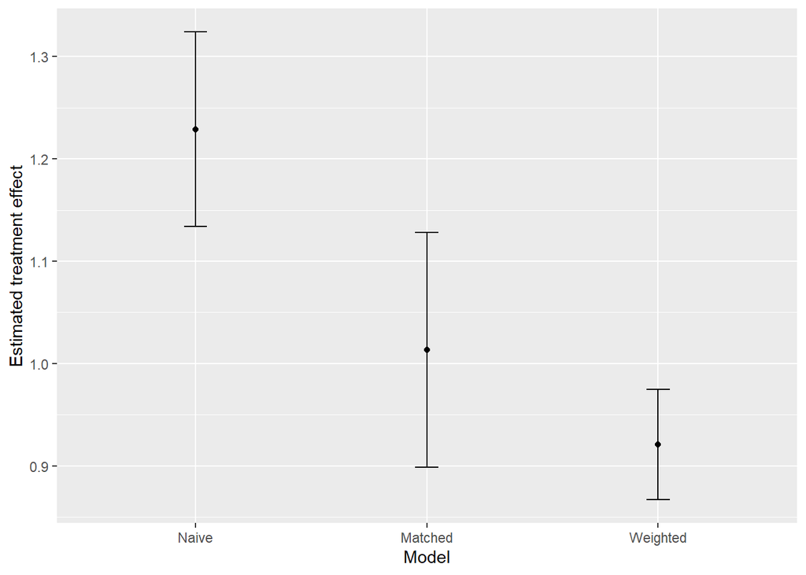

[output not shown]

[output cut: 250 more lines]

[output not shown]